# Risk Factor Analysis

## Outcome Variable

**Outcome Variable:** dead

## Predictor Variables

**Intervention Variable:** ever_wasted06

**Adjustment Set:**

unadjusted

## Stratifying Variables

The analysis was stratified on these variable(s):

- studyid
- country

## Data Summary

| studyid | country | ever_wasted06 | dead | n_cell | n | outcome_variable |
| --- | --- | --- | --- | --- | --- | --- |
| Burkina Faso Zn | BURKINA FASO | 0 | 0 | 296 | 338 | dead |
| Burkina Faso Zn | BURKINA FASO | 0 | 1 | 2 | 338 | dead |
| Burkina Faso Zn | BURKINA FASO | 1 | 0 | 40 | 338 | dead |
| Burkina Faso Zn | BURKINA FASO | 1 | 1 | 0 | 338 | dead |
| EE | PAKISTAN | 0 | 0 | 248 | 380 | dead |
| EE | PAKISTAN | 0 | 1 | 2 | 380 | dead |
| EE | PAKISTAN | 1 | 0 | 128 | 380 | dead |
| EE | PAKISTAN | 1 | 1 | 2 | 380 | dead |
| GMS-Nepal | NEPAL | 0 | 0 | 422 | 686 | dead |
| GMS-Nepal | NEPAL | 0 | 1 | 5 | 686 | dead |
| GMS-Nepal | NEPAL | 1 | 0 | 257 | 686 | dead |
| GMS-Nepal | NEPAL | 1 | 1 | 2 | 686 | dead |
| iLiNS-DOSE | MALAWI | 0 | 0 | 1675 | 1814 | dead |
| iLiNS-DOSE | MALAWI | 0 | 1 | 110 | 1814 | dead |
| iLiNS-DOSE | MALAWI | 1 | 0 | 25 | 1814 | dead |
| iLiNS-DOSE | MALAWI | 1 | 1 | 4 | 1814 | dead |
| iLiNS-DYAD-M | MALAWI | 0 | 0 | 1091 | 1182 | dead |
| iLiNS-DYAD-M | MALAWI | 0 | 1 | 33 | 1182 | dead |
| iLiNS-DYAD-M | MALAWI | 1 | 0 | 53 | 1182 | dead |
| iLiNS-DYAD-M | MALAWI | 1 | 1 | 5 | 1182 | dead |
| JiVitA-3 | BANGLADESH | 0 | 0 | 21075 | 26918 | dead |
| JiVitA-3 | BANGLADESH | 0 | 1 | 399 | 26918 | dead |
| JiVitA-3 | BANGLADESH | 1 | 0 | 5282 | 26918 | dead |
| JiVitA-3 | BANGLADESH | 1 | 1 | 162 | 26918 | dead |
| JiVitA-4 | BANGLADESH | 0 | 0 | 4521 | 5252 | dead |
| JiVitA-4 | BANGLADESH | 0 | 1 | 37 | 5252 | dead |
| JiVitA-4 | BANGLADESH | 1 | 0 | 684 | 5252 | dead |
| JiVitA-4 | BANGLADESH | 1 | 1 | 10 | 5252 | dead |
| Keneba | GAMBIA | 0 | 0 | 1763 | 2480 | dead |
| Keneba | GAMBIA | 0 | 1 | 33 | 2480 | dead |
| Keneba | GAMBIA | 1 | 0 | 660 | 2480 | dead |
| Keneba | GAMBIA | 1 | 1 | 24 | 2480 | dead |
| MAL-ED | BANGLADESH | 0 | 0 | 201 | 263 | dead |
| MAL-ED | BANGLADESH | 0 | 1 | 2 | 263 | dead |
| MAL-ED | BANGLADESH | 1 | 0 | 60 | 263 | dead |
| MAL-ED | BANGLADESH | 1 | 1 | 0 | 263 | dead |
| MAL-ED | INDIA | 0 | 0 | 166 | 251 | dead |
| MAL-ED | INDIA | 0 | 1 | 1 | 251 | dead |
| MAL-ED | INDIA | 1 | 0 | 83 | 251 | dead |
| MAL-ED | INDIA | 1 | 1 | 1 | 251 | dead |
| MAL-ED | PERU | 0 | 0 | 289 | 302 | dead |
| MAL-ED | PERU | 0 | 1 | 2 | 302 | dead |
| MAL-ED | PERU | 1 | 0 | 11 | 302 | dead |
| MAL-ED | PERU | 1 | 1 | 0 | 302 | dead |
| MAL-ED | SOUTH AFRICA | 0 | 0 | 276 | 312 | dead |
| MAL-ED | SOUTH AFRICA | 0 | 1 | 0 | 312 | dead |
| MAL-ED | SOUTH AFRICA | 1 | 0 | 36 | 312 | dead |
| MAL-ED | SOUTH AFRICA | 1 | 1 | 0 | 312 | dead |
| MAL-ED | TANZANIA, UNITED REPUBLIC OF | 0 | 0 | 244 | 261 | dead |
| MAL-ED | TANZANIA, UNITED REPUBLIC OF | 0 | 1 | 3 | 261 | dead |
| MAL-ED | TANZANIA, UNITED REPUBLIC OF | 1 | 0 | 14 | 261 | dead |
| MAL-ED | TANZANIA, UNITED REPUBLIC OF | 1 | 1 | 0 | 261 | dead |
| PROVIDE | BANGLADESH | 0 | 0 | 515 | 700 | dead |
| PROVIDE | BANGLADESH | 0 | 1 | 4 | 700 | dead |
| PROVIDE | BANGLADESH | 1 | 0 | 181 | 700 | dead |
| PROVIDE | BANGLADESH | 1 | 1 | 0 | 700 | dead |
| SAS-CompFeed | INDIA | 0 | 0 | 1142 | 1508 | dead |
| SAS-CompFeed | INDIA | 0 | 1 | 22 | 1508 | dead |
| SAS-CompFeed | INDIA | 1 | 0 | 330 | 1508 | dead |
| SAS-CompFeed | INDIA | 1 | 1 | 14 | 1508 | dead |
| SAS-FoodSuppl | INDIA | 0 | 0 | 316 | 418 | dead |
| SAS-FoodSuppl | INDIA | 0 | 1 | 2 | 418 | dead |
| SAS-FoodSuppl | INDIA | 1 | 0 | 96 | 418 | dead |
| SAS-FoodSuppl | INDIA | 1 | 1 | 4 | 418 | dead |
| TanzaniaChild2 | TANZANIA, UNITED REPUBLIC OF | 0 | 0 | 2038 | 2396 | dead |
| TanzaniaChild2 | TANZANIA, UNITED REPUBLIC OF | 0 | 1 | 1 | 2396 | dead |
| TanzaniaChild2 | TANZANIA, UNITED REPUBLIC OF | 1 | 0 | 357 | 2396 | dead |
| TanzaniaChild2 | TANZANIA, UNITED REPUBLIC OF | 1 | 1 | 0 | 2396 | dead |
| VITAMIN-A | INDIA | 0 | 0 | 2967 | 3895 | dead |
| VITAMIN-A | INDIA | 0 | 1 | 36 | 3895 | dead |
| VITAMIN-A | INDIA | 1 | 0 | 853 | 3895 | dead |
| VITAMIN-A | INDIA | 1 | 1 | 39 | 3895 | dead |
| ZVITAMBO | ZIMBABWE | 0 | 0 | 10499 | 13862 | dead |
| ZVITAMBO | ZIMBABWE | 0 | 1 | 728 | 13862 | dead |
| ZVITAMBO | ZIMBABWE | 1 | 0 | 2316 | 13862 | dead |
| ZVITAMBO | ZIMBABWE | 1 | 1 | 319 | 13862 | dead |

The following strata were considered:

- studyid: Burkina Faso Zn, country: BURKINA FASO
- studyid: EE, country: PAKISTAN
- studyid: GMS-Nepal, country: NEPAL
- studyid: iLiNS-DOSE, country: MALAWI
- studyid: iLiNS-DYAD-M, country: MALAWI
- studyid: JiVitA-3, country: BANGLADESH
- studyid: JiVitA-4, country: BANGLADESH
- studyid: Keneba, country: GAMBIA
- studyid: MAL-ED, country: BANGLADESH
- studyid: MAL-ED, country: INDIA
- studyid: MAL-ED, country: PERU
- studyid: MAL-ED, country: SOUTH AFRICA
- studyid: MAL-ED, country: TANZANIA, UNITED REPUBLIC OF
- studyid: PROVIDE, country: BANGLADESH
- studyid: SAS-CompFeed, country: INDIA
- studyid: SAS-FoodSuppl, country: INDIA
- studyid: TanzaniaChild2, country: TANZANIA, UNITED REPUBLIC OF
- studyid: VITAMIN-A, country: INDIA
- studyid: ZVITAMBO, country: ZIMBABWE

### Dropped Strata

Some strata were dropped due to rare outcomes:

- studyid: Burkina Faso Zn, country: BURKINA FASO
- studyid: EE, country: PAKISTAN
- studyid: GMS-Nepal, country: NEPAL
- studyid: iLiNS-DOSE, country: MALAWI
- studyid: MAL-ED, country: BANGLADESH
- studyid: MAL-ED, country: INDIA
- studyid: MAL-ED, country: PERU
- studyid: MAL-ED, country: SOUTH AFRICA
- studyid: MAL-ED, country: TANZANIA, UNITED REPUBLIC OF
- studyid: PROVIDE, country: BANGLADESH
- studyid: SAS-FoodSuppl, country: INDIA
- studyid: TanzaniaChild2, country: TANZANIA, UNITED REPUBLIC OF

## Methods Detail

We’re interested in the causal parameters $E[Y_a]$ for all values of $a \in \mathcal{A}$. These parameters represent the mean outcome if, possibly contrary to fact, we intervened to set all units to have $A=a$. Under the randomization and positivity assumptions, these are identified by the statistical parameters $\psi_a=E_W[E_{Y|A,W}(Y|A=a,W)]$. In addition, we’re interested in the mean of $Y$, $E[Y]$ under no intervention (the observed mean). We will estimate these parameters by using SuperLearner to fit the relevant likelihood factors – $E_{Y|A,W}(Y|A=a,W)$ and $p(A=a|W)$, and then updating our likelihood fit using a joint TMLE.

For unadjusted analyses ($W=\{\}$), initial likelihoods were estimated using Lrnr_glm to estimate the simple $E(Y|A)$ and Lrnr_mean to estimate $p(A)$. For adjusted analyses, a small library containing Lrnr_glmnet, Lrnr_xgboost, and Lrnr_mean was used.

Having estimated these parameters, we will then use the delta method to estimate relative risks and attributable risks relative to a prespecified baseline level of $A$.

# Results Detail

## Results Plots

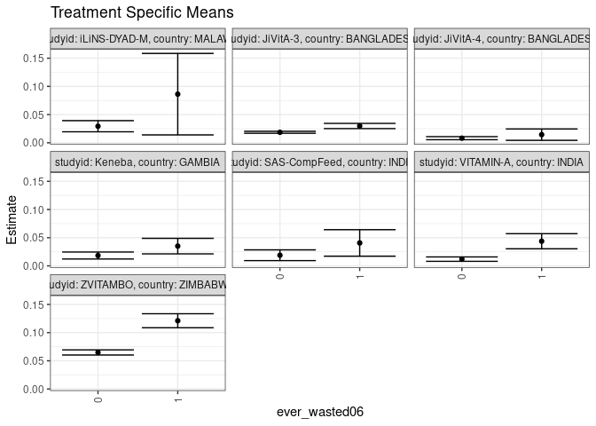

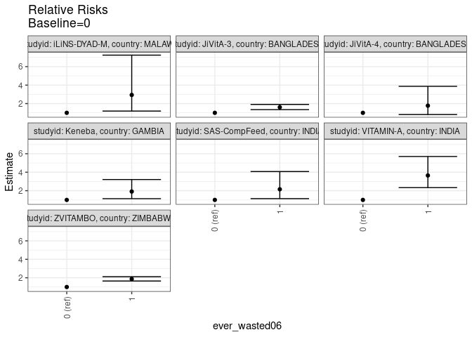

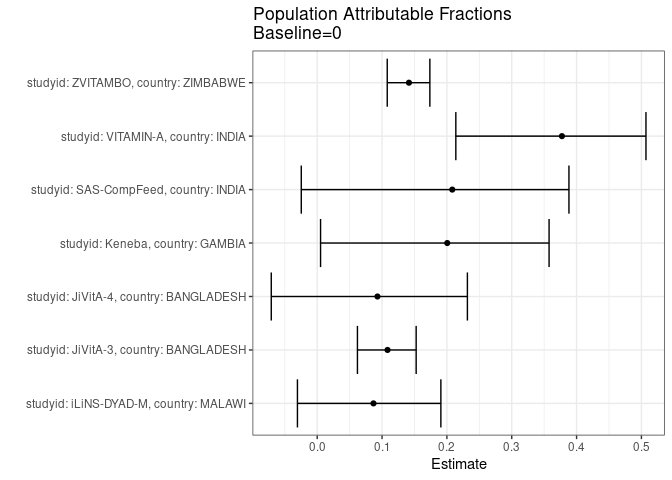

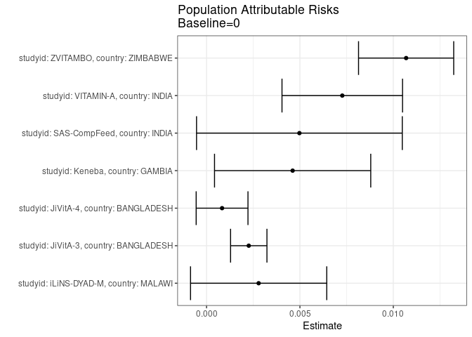

## Results Table

### Parameter: TSM

| studyid | country | intervention_level | baseline_level | estimate | ci_lower | ci_upper |
| --- | --- | --- | --- | --- | --- | --- |
| iLiNS-DYAD-M | MALAWI | 0 | NA | 0.0293594 | 0.0194864 | 0.0392325 |
| iLiNS-DYAD-M | MALAWI | 1 | NA | 0.0862069 | 0.0139444 | 0.1584694 |
| JiVitA-3 | BANGLADESH | 0 | NA | 0.0185806 | 0.0168083 | 0.0203529 |
| JiVitA-3 | BANGLADESH | 1 | NA | 0.0297575 | 0.0251549 | 0.0343602 |
| JiVitA-4 | BANGLADESH | 0 | NA | 0.0081176 | 0.0053939 | 0.0108413 |
| JiVitA-4 | BANGLADESH | 1 | NA | 0.0144092 | 0.0043006 | 0.0245178 |
| Keneba | GAMBIA | 0 | NA | 0.0183742 | 0.0121618 | 0.0245866 |
| Keneba | GAMBIA | 1 | NA | 0.0350877 | 0.0212957 | 0.0488798 |
| SAS-CompFeed | INDIA | 0 | NA | 0.0189003 | 0.0093894 | 0.0284113 |
| SAS-CompFeed | INDIA | 1 | NA | 0.0406977 | 0.0171911 | 0.0642042 |
| VITAMIN-A | INDIA | 0 | NA | 0.0119880 | 0.0080950 | 0.0158810 |
| VITAMIN-A | INDIA | 1 | NA | 0.0437220 | 0.0303016 | 0.0571423 |
| ZVITAMBO | ZIMBABWE | 0 | NA | 0.0648437 | 0.0602885 | 0.0693989 |
| ZVITAMBO | ZIMBABWE | 1 | NA | 0.1210626 | 0.1086072 | 0.1335180 |

### Parameter: E(Y)

| studyid | country | intervention_level | baseline_level | estimate | ci_lower | ci_upper |
| --- | --- | --- | --- | --- | --- | --- |
| iLiNS-DYAD-M | MALAWI | NA | NA | 0.0321489 | 0.0220886 | 0.0422092 |
| JiVitA-3 | BANGLADESH | NA | NA | 0.0208411 | 0.0190926 | 0.0225895 |
| JiVitA-4 | BANGLADESH | NA | NA | 0.0089490 | 0.0062382 | 0.0116597 |
| Keneba | GAMBIA | NA | NA | 0.0229839 | 0.0170850 | 0.0288828 |
| SAS-CompFeed | INDIA | NA | NA | 0.0238727 | 0.0131072 | 0.0346381 |
| VITAMIN-A | INDIA | NA | NA | 0.0192555 | 0.0149392 | 0.0235717 |
| ZVITAMBO | ZIMBABWE | NA | NA | 0.0755302 | 0.0711312 | 0.0799293 |

### Parameter: RR

| studyid | country | intervention_level | baseline_level | estimate | ci_lower | ci_upper |
| --- | --- | --- | --- | --- | --- | --- |
| iLiNS-DYAD-M | MALAWI | 0 | 0 | 1.000000 | 1.0000000 | 1.000000 |
| iLiNS-DYAD-M | MALAWI | 1 | 0 | 2.936259 | 1.1899998 | 7.245058 |
| JiVitA-3 | BANGLADESH | 0 | 0 | 1.000000 | 1.0000000 | 1.000000 |
| JiVitA-3 | BANGLADESH | 1 | 0 | 1.601537 | 1.3436363 | 1.908940 |
| JiVitA-4 | BANGLADESH | 0 | 0 | 1.000000 | 1.0000000 | 1.000000 |
| JiVitA-4 | BANGLADESH | 1 | 0 | 1.775060 | 0.8149034 | 3.866519 |
| Keneba | GAMBIA | 0 | 0 | 1.000000 | 1.0000000 | 1.000000 |
| Keneba | GAMBIA | 1 | 0 | 1.909623 | 1.1370363 | 3.207161 |
| SAS-CompFeed | INDIA | 0 | 0 | 1.000000 | 1.0000000 | 1.000000 |
| SAS-CompFeed | INDIA | 1 | 0 | 2.153277 | 1.1387933 | 4.071504 |
| VITAMIN-A | INDIA | 0 | 0 | 1.000000 | 1.0000000 | 1.000000 |
| VITAMIN-A | INDIA | 1 | 0 | 3.647141 | 2.3328655 | 5.701846 |
| ZVITAMBO | ZIMBABWE | 0 | 0 | 1.000000 | 1.0000000 | 1.000000 |
| ZVITAMBO | ZIMBABWE | 1 | 0 | 1.866992 | 1.6483077 | 2.114689 |

### Parameter: PAR

| studyid | country | intervention_level | baseline_level | estimate | ci_lower | ci_upper |
| --- | --- | --- | --- | --- | --- | --- |
| iLiNS-DYAD-M | MALAWI | 0 | NA | 0.0027895 | -0.0008572 | 0.0064362 |
| JiVitA-3 | BANGLADESH | 0 | NA | 0.0022605 | 0.0012869 | 0.0032340 |
| JiVitA-4 | BANGLADESH | 0 | NA | 0.0008314 | -0.0005557 | 0.0022184 |
| Keneba | GAMBIA | 0 | NA | 0.0046097 | 0.0004273 | 0.0087921 |
| SAS-CompFeed | INDIA | 0 | NA | 0.0049723 | -0.0005357 | 0.0104804 |
| VITAMIN-A | INDIA | 0 | NA | 0.0072674 | 0.0040400 | 0.0104948 |
| ZVITAMBO | ZIMBABWE | 0 | NA | 0.0106865 | 0.0081389 | 0.0132341 |

### Parameter: PAF

| studyid | country | intervention_level | baseline_level | estimate | ci_lower | ci_upper |
| --- | --- | --- | --- | --- | --- | --- |
| iLiNS-DYAD-M | MALAWI | 0 | NA | 0.0867672 | -0.0305119 | 0.1906991 |
| JiVitA-3 | BANGLADESH | 0 | NA | 0.1084620 | 0.0620250 | 0.1525999 |
| JiVitA-4 | BANGLADESH | 0 | NA | 0.0929019 | -0.0708635 | 0.2316229 |
| Keneba | GAMBIA | 0 | NA | 0.2005627 | 0.0051517 | 0.3575904 |
| SAS-CompFeed | INDIA | 0 | NA | 0.2082856 | -0.0245883 | 0.3882307 |
| VITAMIN-A | INDIA | 0 | NA | 0.3774226 | 0.2137743 | 0.5070084 |
| ZVITAMBO | ZIMBABWE | 0 | NA | 0.1414870 | 0.1079976 | 0.1737191 |